# Day 2, PART1

### Read in sample metadata

We also need to read in the sample annotation that we downloaded from the SRA, which contains sample labels, experimental labels, and sequencing run information, etc.

```r
# read in the file from the SRA that has sample/experimental labels
sra_res <- read.csv("/Users/OwenW/Desktop/sra_result.csv", row.names=1)
head(sra_res)
```

```
##                                               Experiment.Title Organism.Name
## SRX384360   GSM1275877: N061011_Alb_Dex; Homo sapiens; RNA-Seq  Homo sapiens
## SRX384359       GSM1275876: N061011_Alb; Homo sapiens; RNA-Seq  Homo sapiens
## SRX384358       GSM1275875: N061011_Dex; Homo sapiens; RNA-Seq  Homo sapiens
## SRX384357 GSM1275874: N061011_untreated; Homo sapiens; RNA-Seq  Homo sapiens
## SRX384356   GSM1275873: N080611_Alb_Dex; Homo sapiens; RNA-Seq  Homo sapiens
## SRX384355       GSM1275872: N080611_Alb; Homo sapiens; RNA-Seq  Homo sapiens
##                    Instrument Submitter Study.Accession
## SRX384360 Illumina HiSeq 2000       GEO       SRP033351
## SRX384359 Illumina HiSeq 2000       GEO       SRP033351
## SRX384358 Illumina HiSeq 2000       GEO       SRP033351
## SRX384357 Illumina HiSeq 2000       GEO       SRP033351
## SRX384356 Illumina HiSeq 2000       GEO       SRP033351
## SRX384355 Illumina HiSeq 2000       GEO       SRP033351
##                                                                                  Study.Title
## SRX384360 Human Airway Smooth Muscle Transcriptome Changes in Response to Asthma Medications
## SRX384359 Human Airway Smooth Muscle Transcriptome Changes in Response to Asthma Medications
## SRX384358 Human Airway Smooth Muscle Transcriptome Changes in Response to Asthma Medications
## SRX384357 Human Airway Smooth Muscle Transcriptome Changes in Response to Asthma Medications
## SRX384356 Human Airway Smooth Muscle Transcriptome Changes in Response to Asthma Medications
## SRX384355 Human Airway Smooth Muscle Transcriptome Changes in Response to Asthma Medications
##           Sample.Accession Sample.Title Total.Size..Mb Total.RUNs Total.Spots
## SRX384360        SRS508581           NA        2269.81          1    31099538
## SRX384359        SRS508582           NA        2006.00          1    28406812
## SRX384358        SRS508580           NA        2449.87          1    41152075
## SRX384357        SRS508579           NA        2109.13          1    34575286
## SRX384356        SRS508577           NA        2006.23          1    31533740
## SRX384355        SRS508578           NA        2354.22          1    30441200
##           Total.Bases Library.Name Library.Strategy Library.Source
## SRX384360  3918541788           NA          RNA-Seq TRANSCRIPTOMIC
## SRX384359  3562039593           NA          RNA-Seq TRANSCRIPTOMIC
## SRX384358  4072315905           NA          RNA-Seq TRANSCRIPTOMIC
## SRX384357  3518623962           NA          RNA-Seq TRANSCRIPTOMIC
## SRX384356  3380181525           NA          RNA-Seq TRANSCRIPTOMIC
## SRX384355  3835591200           NA          RNA-Seq TRANSCRIPTOMIC
##           Library.Selection
## SRX384360              cDNA
## SRX384359              cDNA
## SRX384358              cDNA
## SRX384357              cDNA
## SRX384356              cDNA
## SRX384355              cDNA
```

```r
# rename the Sample.Accession column as Sample so that we can merge with the run info, which we will load next
sra_res$Sample <- sra_res$Sample.Accession
head(sra_res)
```

```
##                                               Experiment.Title Organism.Name
## SRX384360   GSM1275877: N061011_Alb_Dex; Homo sapiens; RNA-Seq  Homo sapiens
## SRX384359       GSM1275876: N061011_Alb; Homo sapiens; RNA-Seq  Homo sapiens
## SRX384358       GSM1275875: N061011_Dex; Homo sapiens; RNA-Seq  Homo sapiens
## SRX384357 GSM1275874: N061011_untreated; Homo sapiens; RNA-Seq  Homo sapiens
## SRX384356   GSM1275873: N080611_Alb_Dex; Homo sapiens; RNA-Seq  Homo sapiens
## SRX384355       GSM1275872: N080611_Alb; Homo sapiens; RNA-Seq  Homo sapiens
##                    Instrument Submitter Study.Accession
## SRX384360 Illumina HiSeq 2000       GEO       SRP033351
## SRX384359 Illumina HiSeq 2000       GEO       SRP033351
## SRX384358 Illumina HiSeq 2000       GEO       SRP033351
## SRX384357 Illumina HiSeq 2000       GEO       SRP033351
## SRX384356 Illumina HiSeq 2000       GEO       SRP033351
## SRX384355 Illumina HiSeq 2000       GEO       SRP033351
##                                                                                  Study.Title
## SRX384360 Human Airway Smooth Muscle Transcriptome Changes in Response to Asthma Medications
## SRX384359 Human Airway Smooth Muscle Transcriptome Changes in Response to Asthma Medications
## SRX384358 Human Airway Smooth Muscle Transcriptome Changes in Response to Asthma Medications
## SRX384357 Human Airway Smooth Muscle Transcriptome Changes in Response to Asthma Medications
## SRX384356 Human Airway Smooth Muscle Transcriptome Changes in Response to Asthma Medications
## SRX384355 Human Airway Smooth Muscle Transcriptome Changes in Response to Asthma Medications
##           Sample.Accession Sample.Title Total.Size..Mb Total.RUNs Total.Spots
## SRX384360        SRS508581           NA        2269.81          1    31099538
## SRX384359        SRS508582           NA        2006.00          1    28406812
## SRX384358        SRS508580           NA        2449.87          1    41152075
## SRX384357        SRS508579           NA        2109.13          1    34575286
## SRX384356        SRS508577           NA        2006.23          1    31533740
## SRX384355        SRS508578           NA        2354.22          1    30441200
##           Total.Bases Library.Name Library.Strategy Library.Source
## SRX384360  3918541788           NA          RNA-Seq TRANSCRIPTOMIC
## SRX384359  3562039593           NA          RNA-Seq TRANSCRIPTOMIC
## SRX384358  4072315905           NA          RNA-Seq TRANSCRIPTOMIC
## SRX384357  3518623962           NA          RNA-Seq TRANSCRIPTOMIC
## SRX384356  3380181525           NA          RNA-Seq TRANSCRIPTOMIC
## SRX384355  3835591200           NA          RNA-Seq TRANSCRIPTOMIC
##           Library.Selection    Sample
## SRX384360              cDNA SRS508581
## SRX384359              cDNA SRS508582
## SRX384358              cDNA SRS508580
## SRX384357              cDNA SRS508579
## SRX384356              cDNA SRS508577
## SRX384355              cDNA SRS508578
```

```r
# read in the file that contains specific info for each sequencing run
sra_run <- read.csv("/Users/OwenW/Desktop/SraRunInfo.csv", row.names=1)
head(sra_run)
```

```
##            ReleaseDate       LoadDate    spots      bases spots_with_mates
## SRR1039508 1/2/14 9:16 11/26/13 16:39 22935521 2889875646         22935521
## SRR1039509 1/2/14 9:16 11/26/13 16:38 21155707 2665619082         21155707
## SRR1039510 1/2/14 9:16 11/26/13 16:41 22852619 2879429994         22852619
## SRR1039511 1/2/14 9:16 11/26/13 16:42 21938637 2764268262         21938637
## SRR1039512 1/2/14 9:16 11/26/13 16:47 28136282 3545171532         28136282
## SRR1039513 1/2/14 9:16 11/26/13 17:02 43356464 3791311776         16823088
##            avgLength size_MB AssemblyName
## SRR1039508       126    1588           NA
## SRR1039509       126    1480           NA
## SRR1039510       126    1593           NA
## SRR1039511       126    1519           NA
## SRR1039512       126    2055           NA
## SRR1039513        87    2271           NA
##                                                                                      download_path
## SRR1039508 https://sra-downloadb.be-md.ncbi.nlm.nih.gov/sos1/sra-pub-run-5/SRR1039508/SRR1039508.1
## SRR1039509 https://sra-downloadb.be-md.ncbi.nlm.nih.gov/sos1/sra-pub-run-5/SRR1039509/SRR1039509.1
## SRR1039510 https://sra-downloadb.be-md.ncbi.nlm.nih.gov/sos1/sra-pub-run-5/SRR1039510/SRR1039510.1
## SRR1039511 https://sra-downloadb.be-md.ncbi.nlm.nih.gov/sos1/sra-pub-run-5/SRR1039511/SRR1039511.1
## SRR1039512 https://sra-downloadb.be-md.ncbi.nlm.nih.gov/sos1/sra-pub-run-5/SRR1039512/SRR1039512.1
## SRR1039513 https://sra-downloadb.be-md.ncbi.nlm.nih.gov/sos1/sra-pub-run-5/SRR1039513/SRR1039513.1
##            Experiment LibraryName LibraryStrategy LibrarySelection
## SRR1039508  SRX384345          NA         RNA-Seq             cDNA
## SRR1039509  SRX384346          NA         RNA-Seq             cDNA
## SRR1039510  SRX384347          NA         RNA-Seq             cDNA
## SRR1039511  SRX384348          NA         RNA-Seq             cDNA
## SRR1039512  SRX384349          NA         RNA-Seq             cDNA
## SRR1039513  SRX384350          NA         RNA-Seq             cDNA
##             LibrarySource LibraryLayout InsertSize InsertDev Platform
## SRR1039508 TRANSCRIPTOMIC        PAIRED          0         0 ILLUMINA
## SRR1039509 TRANSCRIPTOMIC        PAIRED          0         0 ILLUMINA
## SRR1039510 TRANSCRIPTOMIC        PAIRED          0         0 ILLUMINA
## SRR1039511 TRANSCRIPTOMIC        PAIRED          0         0 ILLUMINA
## SRR1039512 TRANSCRIPTOMIC        PAIRED          0         0 ILLUMINA
## SRR1039513 TRANSCRIPTOMIC        PAIRED          0         0 ILLUMINA
##                          Model  SRAStudy  BioProject Study_Pubmed_id ProjectID
## SRR1039508 Illumina HiSeq 2000 SRP033351 PRJNA229998               2    229998
## SRR1039509 Illumina HiSeq 2000 SRP033351 PRJNA229998               2    229998
## SRR1039510 Illumina HiSeq 2000 SRP033351 PRJNA229998               2    229998
## SRR1039511 Illumina HiSeq 2000 SRP033351 PRJNA229998               2    229998
```

[output cut: 22 more lines]

```
## SRR1039513               NA           NA                NA        NA        GEO
##            Submission dbgap_study_accession Consent
## SRR1039508  SRA114259                    NA  public
## SRR1039509  SRA114259                    NA  public
## SRR1039510  SRA114259                    NA  public
## SRR1039511  SRA114259                    NA  public
## SRR1039512  SRA114259                    NA  public
## SRR1039513  SRA114259                    NA  public
##                                     RunHash                         ReadHash
## SRR1039508 65345B22A4745B616DD5840CF2AD90EE 54B084AA7AD2A02B39D37CBBD5B1C3DC
## SRR1039509 E2F5FBD3278F29EC6EA7B00FC95C28B2 294D13FE5364BA88B5FEAD68A53CB11B
## SRR1039510 2019240C219172C77646ED066033D588 16F7F5A040CECD58D73F344710F13D7D
## SRR1039511 D7FCAEEB12F4F5EE4956EDED736E4E4F 0D8679513EAC88ED62C14B488E2134E5
## SRR1039512 828A997474D0BBD6E5E14DEDB0D9E31D 5834A34CA3CE7EF962A396098543C9E6
## SRR1039513 0EB840FF1F4AA22A5017CB754C039225 5A5DD90EDCD5998A26F7F7BC099D4010
```

```r
# lets set the row names (SRR numbers from the SRA, stands for SRA run accession) as a new variable in the dataframe, as we will need it later
sra_run$SRR <- rownames(sra_run)

# merge sra_res and sra_run together so that we get all of the identifiers and experiment info that we will need in the same dataframe
colData <- merge(sra_res, sra_run, merge="Sample")

# order by SRA run accession
colData <- colData[order(colData$SRR),]

# quick look
head(colData)
```

```
##      Sample                                     Experiment.Title Organism.Name
## 2 SRS508568  GSM1275862: N61311_untreated; Homo sapiens; RNA-Seq  Homo sapiens
## 1 SRS508567        GSM1275863: N61311_Dex; Homo sapiens; RNA-Seq  Homo sapiens
## 4 SRS508570        GSM1275864: N61311_Alb; Homo sapiens; RNA-Seq  Homo sapiens
## 3 SRS508569    GSM1275865: N61311_Alb_Dex; Homo sapiens; RNA-Seq  Homo sapiens
## 5 SRS508571 GSM1275866: N052611_untreated; Homo sapiens; RNA-Seq  Homo sapiens
## 6 SRS508572       GSM1275867: N052611_Dex; Homo sapiens; RNA-Seq  Homo sapiens
##            Instrument Submitter Study.Accession
## 2 Illumina HiSeq 2000       GEO       SRP033351
## 1 Illumina HiSeq 2000       GEO       SRP033351
## 4 Illumina HiSeq 2000       GEO       SRP033351
## 3 Illumina HiSeq 2000       GEO       SRP033351
## 5 Illumina HiSeq 2000       GEO       SRP033351
## 6 Illumina HiSeq 2000       GEO       SRP033351
##                                                                          Study.Title
```

[output cut: 90 more lines]

Now that we have the sample metadata loaded, we need to clean up some variables to get the information we need for downstream analysis.

```r
# lets chop up the 'Experiment.Title' variable to extrat the experimental group labels for the experiment
colData$group <- sapply(as.character(colData$Experiment.Title), function(x) strsplit(x, "1_")[[1]][2])
colData$group
```

```
##  [1] "untreated; Homo sapiens; RNA-Seq" "Dex; Homo sapiens; RNA-Seq"
##  [3] "Alb; Homo sapiens; RNA-Seq"       "Alb_Dex; Homo sapiens; RNA-Seq"
##  [5] "untreated; Homo sapiens; RNA-Seq" "Dex; Homo sapiens; RNA-Seq"
##  [7] "Alb; Homo sapiens; RNA-Seq"       "Alb_Dex; Homo sapiens; RNA-Seq"
##  [9] "untreated; Homo sapiens; RNA-Seq" "Dex; Homo sapiens; RNA-Seq"
## [11] "Alb; Homo sapiens; RNA-Seq"       "Alb_Dex; Homo sapiens; RNA-Seq"
## [13] "untreated; Homo sapiens; RNA-Seq" "Dex; Homo sapiens; RNA-Seq"
## [15] "Alb; Homo sapiens; RNA-Seq"       "Alb_Dex; Homo sapiens; RNA-Seq"
```

```r
colData$group <- sapply(as.character(colData$group), function(x) strsplit(x, ";")[[1]][1])
colData$group
```

```
##  [1] "untreated" "Dex"       "Alb"       "Alb_Dex"   "untreated" "Dex"
##  [7] "Alb"       "Alb_Dex"   "untreated" "Dex"       "Alb"       "Alb_Dex"
## [13] "untreated" "Dex"       "Alb"       "Alb_Dex"
```

```r
# now make this a factor as it will be the variable we will use define groups for the differential expression analysis
colData$group <- factor(colData$group, levels=c("untreated", "Dex", "Alb", "Alb_Dex"))
colData$group
```

```
##  [1] untreated Dex       Alb       Alb_Dex   untreated Dex       Alb
##  [8] Alb_Dex   untreated Dex       Alb       Alb_Dex   untreated Dex
## [15] Alb       Alb_Dex
## Levels: untreated Dex Alb Alb_Dex
```

### Construct the DESEq2 data set & explore the characteristics of the data

DESeq2 uses an object class called the (`DESeqDataSet`) that stores the read counts, metadata, experimental design, and all the intermediate values calculated during the analysis. (`DESeqDataSet`) extends the (`SummarizedExperiment`) class object from the (`SummarizedExperiment`) R/Bioconductor package that is commonly used to store data from expression studies and other genomics assays in R.

Three elements are required to generate the (`DESeqDataSet`):  
- matrix of raw counts - sample metadata (colData) - a design formula

The design formula let’s DESeq2 know your experimental design and what groups you want to compare in the differential expression analysis. It requires a variable that is present in colData to be specified, and will be used for the statistical analysis in DESeq2. This varuiable should be a (`factor`) class variable, with the reference group for your comparison set as the first level of the variable.

Lets create the (`DESeqDataSet`) object.

```r
dds <- DESeqDataSetFromMatrix(countData = cts,
                              colData = colData,
                              design = ~ group)
```

We could have also done this using the (`DESeqDataSetFromHTSeqCount()`) function by specifying a (`SampleTable`) that includes the path to the htseq-count files, however since we compiled the read counts into one file, we can just load the dataset directly.

Before moving on, lets explore our DESeq2 class object a bit to get to familar with its contents.

```r
# have a quick look at the object
dds

# print structure
str(dds)

# several accessor functions exist to access specific data 'slots'
head(counts(dds))
head(colData(dds))

# specific slots can also be accessed using the '@'
dds@colData
```

Lets drop genes that have less than 10 reads across all samples, as there just isn’t enough information for these genes to fit robust statistical models to.

```r
# drop genes with low counts
keep <- rowSums(counts(dds)) >= 10
dds <- dds[keep,]
```

Lets also save the DESeq object at this point (so that we don’t have to do the above everytime we want to work with our data).

```r
save(dds, file = "DESeq2.rdata")
```

### Normalization of raw counts

Before comparing expression levels of specific genes between samples, and performing any differential expression analyses, it is important that we normalize the data to account for variation in expression that is not related to true differential expression. There are two major sources variation that we need to adjust for in the normalization process for RNA-seq data when we wish to compare expression levels **between** samples:

1. Library size/sequencing depth

Although we generally try to pool samples together at similar concentrations in a sequencing run, some samples will end up being sequenced more than others, leading to slight differences in how many reads are produced for that sample, and therefore sequencing depth and size. Furthermore, if samples are sequenced on separate runs, their sequencing depths may be very different. If we don’t account for this variation in sequencing depth, we might conclude some genes are expressed at greater levels in a samplen that has simply been sequenced to a higher depth.

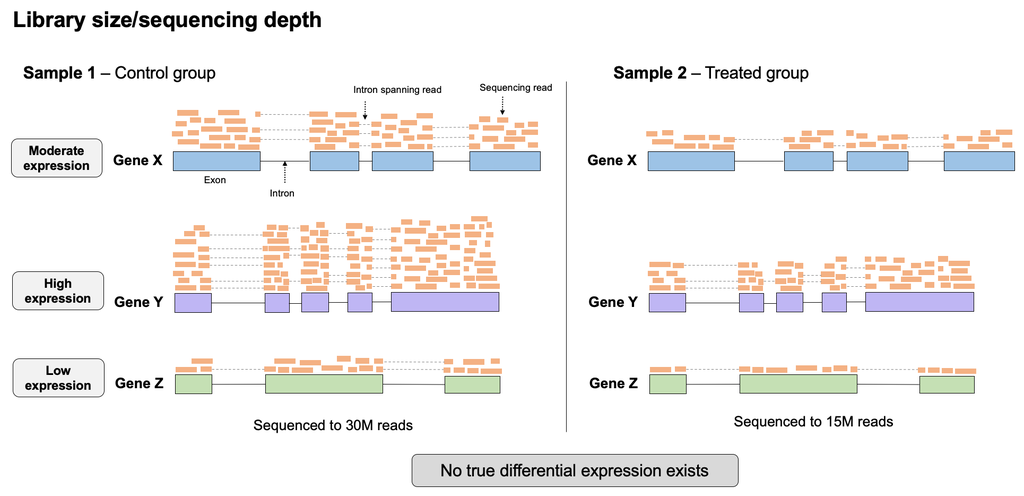

Library size example

2. Library composition

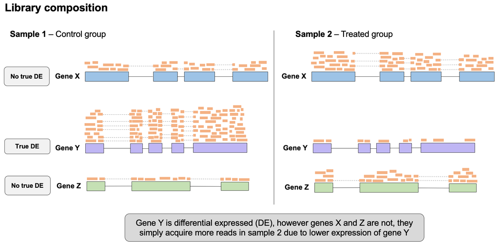

Library composition example

To correct for library size AND library composition, DESeq2 uses a algorithm referred to as the median-of-ratios method. Although we won’t go over how the algorithm works in detail, a brief summary of the steps is:

1. Take the log of all values in raw count matrix
2. Average each row (genes)
3. Filter out genes with Infinity values
4. Subtract average log count value from log of count for each cell (due to the laws of working with logarithms, this is essentially calculating the ratio of the counts for gene X in 1 sample to the average counts for gene X across all samples)
5. Calculate the median of the ratios in each sample (column)
6. Take exponents of medians to get the **size factors** for each sample/library.
7. Divide the count for each gene in each sample by the scaling factor calculated for that sample.

This procedure will generate a matrix of read counts that are corrected for both **library size** and **library composition**, and are stored in our (`DESeqDataset`) object. DESeq2 uses the function (`estimateSizeFactors()`) to perform this algorithm and calculate size factors for each sample. Lets do this for our (`DESeqDataset`).

```r
dds <- estimateSizeFactors(dds)
```

Note: [This video](https://www.youtube.com/watch?v=UFB993xufUU) from StatQuest provides an excellent summary of the steps performed by (`estimateSizeFactors()`) in order to calculate these size factors.

Once we have calculated the size factors, it can be helpful to look at their distribution to get a feel for how they vary and how much normalization between the sample is required.

```r
sizeFactors(dds)
```

```
## SRR1039508 SRR1039509 SRR1039510 SRR1039511 SRR1039512 SRR1039513 SRR1039514
##  0.9546639  0.8379264  0.9559347  0.8841828  1.1063105  0.6305985  1.5002929
## SRR1039515 SRR1039516 SRR1039517 SRR1039518 SRR1039519 SRR1039520 SRR1039521
##  0.9404767  1.1086740  1.3092383  1.1900257  0.8972838  0.8647837  0.8868375
## SRR1039522 SRR1039523
##  1.1550681  1.2038272
```

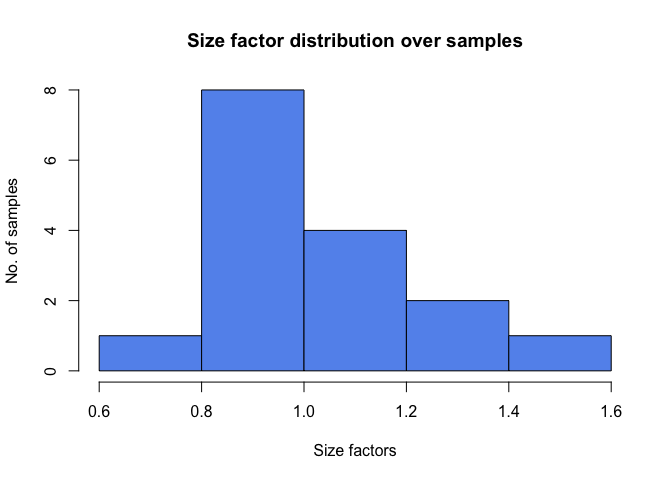

```r
hist(sizeFactors(dds),
     breaks=6, col = "cornflowerblue",
     xlab="Size factors", ylab="No. of samples",
     main= "Size factor distribution over samples")
```

After we have calculated the size factors, we can use the (`counts()`) function, with (`normalized`) set to (`TRUE`), to return the matrix of counts where each column (each library/sample) have been divided by the size factors calculated by the (`estimateSizeFactors()`) function.

```r
counts_norm <- counts(dds, normalized=TRUE)
head(counts_norm)
```

```
##                 SRR1039508 SRR1039509 SRR1039510 SRR1039511 SRR1039512
## ENSG00000000003  731.14734  558.52161   792.9412   532.6952  807.18751
## ENSG00000000419  486.03491  605.06508   475.9739   588.1136  549.57447
## ENSG00000000457  270.25217  245.84498   247.9249   256.7342  236.82321
## ENSG00000000460   60.75436   65.63822    92.0565    64.4663   35.25231
## ENSG00000000971 3048.19305 3935.90655  3595.4340  4330.5522 5038.36860
## ENSG00000001036 1465.43714 1243.54597  1450.9360  1104.9751 1528.50400
##                 SRR1039513 SRR1039514 SRR1039515 SRR1039516 SRR1039517
## ENSG00000000003  666.03391  656.53845  933.56907 1064.33448  820.32433
## ENSG00000000419  566.12882  579.22022  475.29086  523.14746  596.53008
## ENSG00000000457  258.48459  218.62397  230.73404  218.27877  252.05496
## ENSG00000000460   55.50283   57.98868   49.97465   69.45233   48.88339
## ENSG00000000971 6041.87900 7435.21467 6154.32548 5468.69486 7524.22254
## ENSG00000001036 1368.54110 1240.42443 1601.31551 1259.16181 1070.85169
##                 SRR1039518 SRR1039519 SRR1039520 SRR1039521 SRR1039522
## ENSG00000000003  936.11422  1271.6156  927.39954  670.92334  973.96853
## ENSG00000000419  602.50799   568.3821  478.73243  563.80113  463.17614
## ENSG00000000457  247.05348   221.7805  265.96246  258.22092  214.70595
## ENSG00000000460   55.46099    74.6698   87.88325   67.65614   72.72298
## ENSG00000000971 8363.68479  6652.2991 5330.81279 8039.80410 6509.57275
## ENSG00000001036 1052.91842  1292.7906 1535.64412 1223.44845 1523.71965
##                 SRR1039523
## ENSG00000000003  724.35645
## ENSG00000000419  559.05033
## ENSG00000000457  230.09947
## ENSG00000000460   75.59224
## ENSG00000000971 7908.94239
## ENSG00000001036 1145.51324
```

Comparing the normalized to the raw counts, we can clearly see that they are different.

```r
head(counts(dds, normalized=FALSE))
```

```
##                 SRR1039508 SRR1039509 SRR1039510 SRR1039511 SRR1039512
## ENSG00000000003        698        468        758        471        893
## ENSG00000000419        464        507        455        520        608
## ENSG00000000457        258        206        237        227        262
## ENSG00000000460         58         55         88         57         39
## ENSG00000000971       2910       3298       3437       3829       5574
## ENSG00000001036       1399       1042       1387        977       1691
##                 SRR1039513 SRR1039514 SRR1039515 SRR1039516 SRR1039517
## ENSG00000000003        420        985        878       1180       1074
## ENSG00000000419        357        869        447        580        781
## ENSG00000000457        163        328        217        242        330
## ENSG00000000460         35         87         47         77         64
## ENSG00000000971       3810      11155       5788       6063       9851
## ENSG00000001036        863       1861       1506       1396       1402
##                 SRR1039518 SRR1039519 SRR1039520 SRR1039521 SRR1039522
## ENSG00000000003       1114       1141        802        595       1125
## ENSG00000000419        717        510        414        500        535
## ENSG00000000457        294        199        230        229        248
## ENSG00000000460         66         67         76         60         84
## ENSG00000000971       9953       5969       4610       7130       7519
## ENSG00000001036       1253       1160       1328       1085       1760
##                 SRR1039523
## ENSG00000000003        872
## ENSG00000000419        673
## ENSG00000000457        277
## ENSG00000000460         91
## ENSG00000000971       9521
## ENSG00000001036       1379
```

We can use this table of normalized read counts to compare values for individual genes across samples. We might want to use this to (sanity) check the expression of a few genes of interest, before we actually do any statistical modelling. The abstract of the paper describes *DUSP1*, a phosphatase with dual specificity for tyrosine and threonine, as a well-known glucocorticoid-responsive gene.

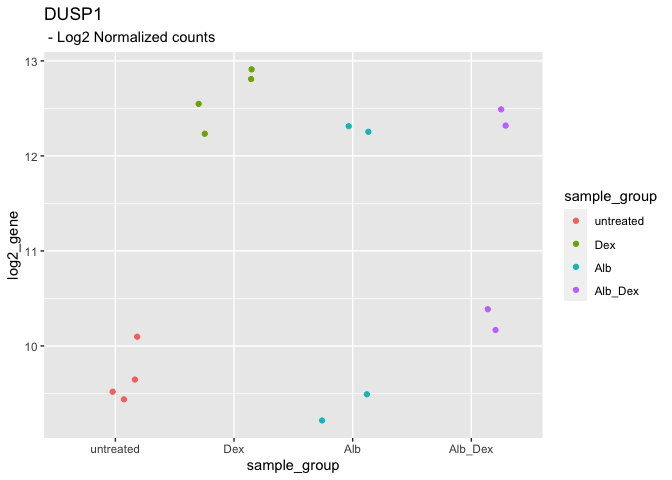

```r
# lets make a function to generate a quick plot of the normalized counts
gene_plot <- function(ENSG, gene_symbol){
  # save the normalized counts in a dataframe
  cnts <- counts(dds, normalized=TRUE)
  colnames(cnts) <- colData(dds)$SRR
  # extract the counts for specified ENSG ID and add sample group data
  df1 <- data.frame(log2(cnts[ENSG,]), colData(dds)$group)
  colnames(df1) <- c(paste0("log2_gene"), "sample_group")
  # use ggplot2 to make a plot of counts vs sample group
  p1<- ggplot(df1, aes(sample_group, log2_gene)) +
    geom_jitter(aes(color = sample_group)) +
    ggtitle(paste0(gene_symbol), " - Log2 Normalized counts")
  # print the plot
  print(p1)
}

# now apply the function to print a plot for a specified gene
gene_plot(ENSG = "ENSG00000120129", gene_symbol = "DUSP1")
```

DUSP1 expression is consistently higher in the DEX samples than the untreated, suggesting this gene is differentially expressed after DEX treatment, validating prior knowledge and giving us confidence that our experiment worked, sample labels are all correct, and we are well positioned to make new discoveries with these data.

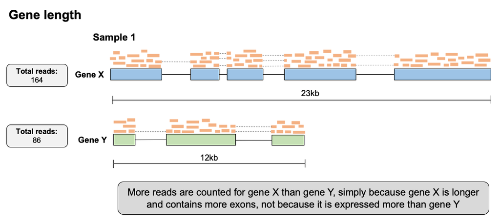

Gene length example

### Exploratory data analysis & quality control

Before we run the differential expression analysis, we should explore our dataset to learn a little more about it. Importantly, we should determine how samples are related to each other based on their gene expression profiles, make sure our replicates cluster together, assess the potential for any batch effects that may exist, and more generally build expectations for the DE analysis. For these exploratory analyses, we use several unsupervised methods to assess how our samples cluster relative to one another. These unsupervised approached include **principal components analysis (PCA)**, and **unsupervised Hierarchical clustering** and are commonly referred to as *data reduction* appraoches.

### Principal components analysis (PCA)

PCA is a mathematical procedure that calculates vectors which explain the most varition in the dataset (in this case, variation in gene expression), and places samples along these vectors. We would expect samples that are more similar to each other, e.g. replicates, to be very close to each other along these axes of varaition, while we might expect samples in different treatment groups to be further away. Each vector that is calculated is called a principal component (PC), and each principal component explains less varaition in our dataset than the last. e.g, PC1 explains more variation in gene expression differences between the samples than PC2. If we plot PC1 against PC2, samples will ‘cluster’ with other samples that have similar gene expression profiles, and be further away from samples with more distant expression profiles.

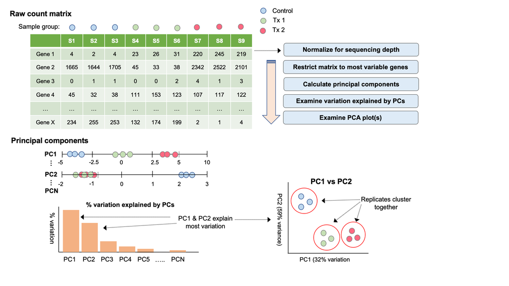

PCA example

Again, StatQuest has an excellent [video](https://www.youtube.com/watch?v=_UVHneBUBW0) that explains the fundamental concepts of PCA, and provoides more details how to the PCs themselves are calculated.

To perform mathematical procedures such as PCA, it is better to work with a transformed version of the counts, rather than the original untransformed values. DESeq2 actually utilizes its own transformation procedure, called the regularized logatrithm (rlog) implemented in the (`rlog()`) function. The rlog is similar in principle to a standard log transformation of the data, but is able to more appropriately transform the counts for gene with low expression values.

DESeq2 is also capable of implementing the variance stabilising transformation (VST) for count data, and is generally suggested for larger datasets due to increase speed.

For this analysis, we will use the rlog, which produces values on the log2 scale and are also normalized for library size during the rlog procedure. Lets perform the rlog transformation on our data.

```r
rld <- rlog(dds, blind = FALSE)
head(assay(rld))
```

```
##                 SRR1039508 SRR1039509 SRR1039510 SRR1039511 SRR1039512
## ENSG00000000003   9.553915   9.293960   9.634062   9.248913   9.651762
## ENSG00000000419   8.975079   9.189020   8.954938   9.161026   9.094500
## ENSG00000000457   8.020479   7.932336   7.940192   7.972483   7.897862
## ENSG00000000460   5.957300   6.012633   6.272144   5.999742   5.602442
## ENSG00000000971  11.859681  12.108263  12.019403  12.202862  12.354590
## ENSG00000001036  10.468316  10.302750  10.458210  10.185346  10.511347
##                 SRR1039513 SRR1039514 SRR1039515 SRR1039516 SRR1039517
## ENSG00000000003   9.463634   9.448013   9.797468   9.930933   9.667877
## ENSG00000000419   9.123299   9.146374   8.953586   9.046305   9.175449
## ENSG00000000457   7.978110   7.824048   7.874069   7.823220   7.955786
## ENSG00000000460   5.898212   5.922434   5.823606   6.055080   5.804083
## ENSG00000000971  12.539505  12.754418  12.558474  12.437680  12.766821
## ENSG00000001036  10.398871  10.300084  10.558848  10.315172  10.153987
##                 SRR1039518 SRR1039519 SRR1039520 SRR1039521 SRR1039522
## ENSG00000000003   9.800475  10.113804   9.790676   9.469947   9.840594
## ENSG00000000419   9.185251   9.127448   8.960671   9.119496   8.928404
## ENSG00000000457   7.937042   7.838148   8.005290   7.977851   7.808157
## ENSG00000000460   5.891935   6.108145   6.233475   6.034777   6.090024
## ENSG00000000971  12.877758  12.638696  12.411750  12.836135  12.616315
## ENSG00000001036  10.137456  10.341643  10.515925  10.286453  10.508171
##                 SRR1039523
## ENSG00000000003   9.544554
## ENSG00000000419   9.111313
## ENSG00000000457   7.871274
## ENSG00000000460   6.119933
## ENSG00000000971  12.819004
## ENSG00000001036  10.220749
```

We can illustrate the benefit of using the rlog over standard log transformation (+ a pseudo-count for genes with 0 counts) by comparing the transformed values for two samples against each other.

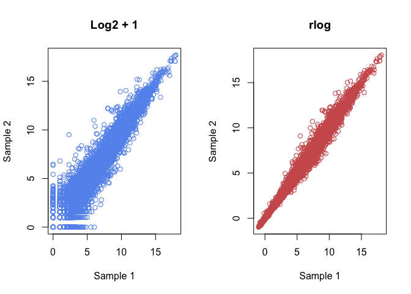

```r
par(mfrow=c(1,2))
plot(log2(cts[,1]+1), log2(cts[,2]+1), col = "cornflowerblue", xlab = "Sample 1", ylab = "Sample 2", main = "Log2 + 1")
plot(assay(rld)[,1], assay(rld)[,2], col = "indianred", xlab = "Sample 1", ylab = "Sample 2", main = "rlog")
```

We can use these transformed values to investigate how many features (genes) in our dataset exhibit variability across samples. This is useful to know as we only want to use variable features for PCA, since genes that don’t explain any variation in the dataset aren’t useful for helping us explore differences between the samples.

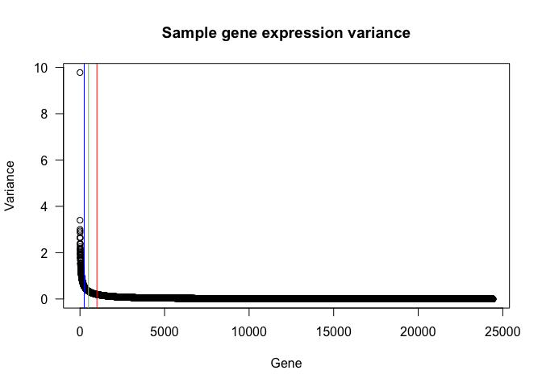

```r
# calculate gene expression level variance between samples
var <- rev(rowVars(assay(rld))[order(rowVars(assay(rld)))])

# plot variance for genes accross samples
plot(var, las = 1, main="Sample gene expression variance", xlab = "Gene", ylab = "Variance")
abline(v=1000, col="red") ; abline(v=500, col="green") ; abline(v=250, col="blue")
```

Looks like 500 is approximately the number of genes at which the variance starts to spike upwards, so this is a good number of variable features to use. Lets restrict the dataset to these genes for purposes of the PCA. Now lets extract and visualize the variance explained by each PC to determine which are most informative.

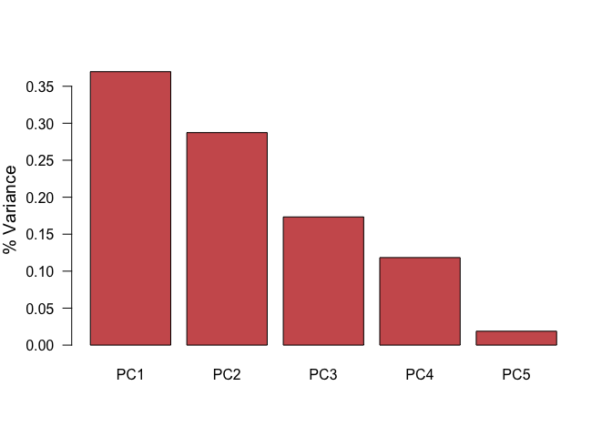

```r
# modify variable feature number to be used in PCA and hierachical clutering based on no. of most variable features
var_feature_n <- 500

# perform PCA and order by variance
rv <- rowVars(assay(rld))
select <- order(rv, decreasing = TRUE)[seq_len(min(var_feature_n, length(rv)))]
pca <- prcomp(t(assay(rld)[select, ]))

# extract the varioance explained by each PC
percentVar <- pca$sdev^2/sum(pca$sdev^2)
names(percentVar)[1:5] <- c("PC1", "PC2", "PC3", "PC4", "PC5")
percentVar <- percentVar[1:5]

# plot variance for top 10 PCs
barplot(percentVar[1:5], col = "indianred", las = 1, ylab = "% Variance", cex.lab = 1.2)
```

We can see that the majority of variance is explained by the first few PCs, therefore visualizing where samples fall along these PCs will be the most informative way to identify major differences between them, based on their gene expression profiles. Lets generate a PCA plot for PC1 vs PC2.

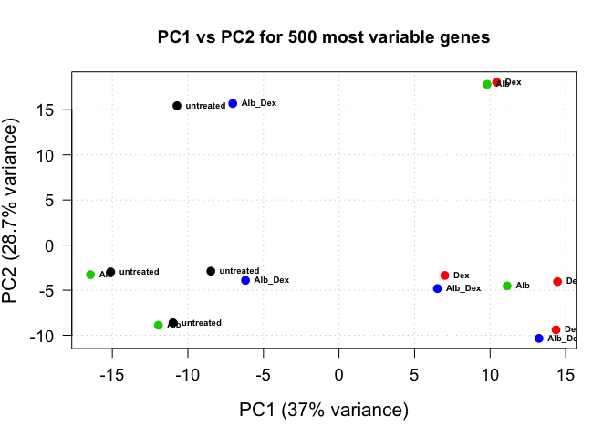

```r
# construct data frame w/ PC loadings and add sample labels
pca_df <- as.data.frame(pca$x)
pca_df$group <- dds@colData$group
pca_df$sample_ids <- colnames(dds)

# add colors for plotting to df
pca_df$col <- NA
for(i in 1:length(levels(pca_df$group))){
  ind1 <- which(pca_df$group == levels(pca_df$group)[i])
  pca_df$col[ind1] <- i
}

# plot PC1 vs PC2
plot(pca_df[, 1], pca_df[, 2],
     xlab = paste0("PC1 (", (round(percentVar[1], digits=3)*100), "% variance)"),
     ylab = paste0("PC2 (", (round(percentVar[2], digits=3)*100), "% variance)"),
     main=paste0("PC1 vs PC2 for ", var_feature_n, " most variable genes"),
     pch=16, cex=1.35, cex.lab=1.3, cex.axis = 1.15, las=1,
     panel.first = grid(),
     col=pca_df$col)
text((pca_df[, 2])~(pca_df[, 1]), labels = pca_df$group, cex=0.6, font=2, pos=4)
```

Looking at the plot, we can see some clear clustering by treatment group for some of the samples. For example, **untreated** samples appear to have much lower PC1 values than all the **Dex** samples, suggesting there some of the largest variability in gene expression differences between samples in this dataset explains differences between **untreated** and **Dex** treated samples, and we should expect the most substantial differential expression to be found for the **untreated** vs **Dex** analysis.

The **Alb** treated samples, and the co-treated samples **(Alb_Dex)** do not seem to consistently cluster along PC1 and PC2. One explanation for this could be that treatment with **Alb** or co-tx with **Alb + Dex** do not lead to consistent gene expression changes across study subjects. This is often the case with *in vivo* data sets, rather than those collected in *in vitro* systems such as cell culture, and may mean that a greater number of replicates is required to accurately assess the impact of such treatment of gene expression, as there are usually a greater number of uncontrollable variables in *in vivo* datasets (e.g. genotype).

It is interesting that 4 samples, 1 from each tx group, have much higher PC2 values than all other samples. This is a pattern we might expect to see if these 4 samples were processed in a separate batch, and the gene expression variation captured by PC2 is related to the batch effect, rather than our biological factor of interest (tx group). For purposes of this example, lets create a fake variable for sample batch, and include this on the PCA plot.

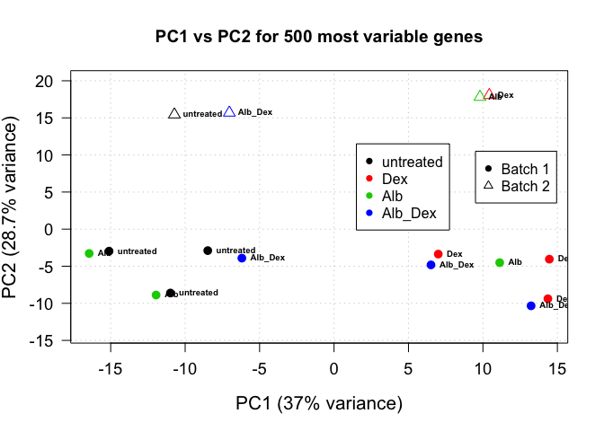

```r
pca_df$batch <- NA
pca_df$batch[pca_df$PC2 < 10] <- "Batch 1"
pca_df$batch[pca_df$PC2 > 10] <- "Batch 2"
pca_df$batch <- factor(pca_df$batch, levels = c("Batch 1", "Batch 2"))

# replot PC1 vs PC2 with the shape set to batch
plot(pca_df[pca_df$batch=="Batch 1", 1], pca_df[pca_df$batch=="Batch 1", 2],
     xlab = paste0("PC1 (", (round(percentVar[1], digits=3)*100), "% variance)"),
     ylab = paste0("PC2 (", (round(percentVar[2], digits=3)*100), "% variance)"),
     main=paste0("PC1 vs PC2 for ", var_feature_n, " most variable genes"),
     pch=16, cex=1.35, cex.lab=1.3, cex.axis = 1.15, las=1,
     panel.first = grid(),
     col=pca_df$col,
     ylim=c(-14,20))
points(pca_df[pca_df$batch=="Batch 2", 1], pca_df[pca_df$batch=="Batch 2", 2],
       col=pca_df$col,
       pch=2, cex=1.35)
legend(9.5, 10.5, levels(pca_df$batch), pch = c(16, 2))
legend(1.5, 11.5, levels(pca_df$group), pch = 16, col = pca_df$col)
text((pca_df[, 2])~(pca_df[, 1]), labels = pca_df$group, cex=0.6, font=2, pos=4)
```

If this was a real batch variable, this would clearly indicate a batch effect. If batch is not accounted for in the differential expression analysis, these samples will increase the per gene variance (and therefore dispersion paracmeter in the negative-binomial model) and prevent the detection of genes that are truly differentially expressed between our experimental conditions of interest, effectively reducing statistical power. This could lead to both false-negatives and false-positives.

If you detect a batch effect in your data, you can try to: * use a statistical prcedure to remove the batch effect from your data * adjust for batch as a term in your statistical model when running differential expression * remove the samples driving the batch effect, if you have a particular reason to suspect these specific samples

How you handle a batch effect is a complicated issue, and is largely dependent on the extent of the batch effect. If the batch effect is very large, it may be too diffcult to effectively remove it statistically, or regress out variation attributable to it in the DE analysis. This is where practicing your protcol and confirming you can get consistent results across replciates and batches comes in. If you do this work ahead of time, you reduce the risk of having to deal with this complicated batch effect in the analysis.

If your experiment includes multiple batches, you should always include them in your unsupervised analyses to check for a batch effect.

### Hierarchical clustering

Hierarchical clustering is another complimentary approach to explore the relationships between your samples. While supervised clustering approaches exist, we will perform an unsupervised analysis so that we do not impose any restrictions on the clustering of the samples.

Hierachical clustering is often associated with heatmaps, as it is a useful way to explore the results of hierachical clustering. Here we represent genes are rows, and individual samples as columns. The denrograms on the rows and the columns represent the ‘distances’ calculated between each of the genes/samples. Presenting the data in this way is useful as it allows us to identify samples whose gene expression programs are similar to each other, but also modules of genes that change similarly across our samples, and may share some common function of interest.

The first step in a hierachical clustering analaysis is to *scale your data*. This means that expression levels are all transformed onto the same scale before clustering. This is important to do as we can only visualize so many colors at once, and a very highly expressed gene would mean that all the other genes would essentially invisible on this scale. Scaling for clustering in this way is typically performed by calculating Z-scores, where the mean for each gene across all the samples is subtracted from each of the individual expression values for each gene, which centers the values around 0. We then divide these values by the standard deviation to make sure the data is more tightly grouped, which helps us represent lots of genes in the same scale.

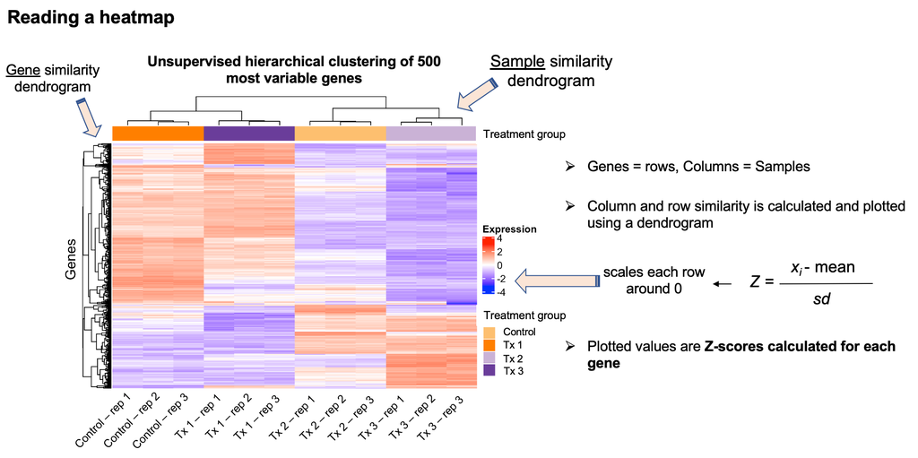

Hierarchical clustering example

Although we will not go into full detail here on how the actual clustering algorithm works to group samples and genes, once more StatQuest has an [excellent video](https://www.youtube.com/watch?v=oMtDyOn2TCc) on this topic.

Similarly to the PCA, we perform the clustering using the rlog transformed data and the 500 most variable features, as features that do not vary across samples are not informative for dimension reduction appraoches.

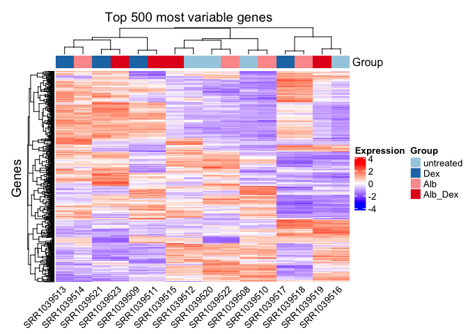

```r
# select top X no. of variable genes
topVarGenes <- head(order(rowVars(assay(rld)), decreasing=TRUE), var_feature_n)

# set up gene expression matrix
mat1 <- assay(rld)[topVarGenes,]

# scale matrix by each col. values
mat_scaled = t(apply(mat1, 1, scale))

# set up colors for heatmap
col = colorRamp2(c(-3, 0, 3), c("blue", "white", "red"))
cols1 <- brewer.pal(11, "Paired")
cols2 <- brewer.pal(9, "Greens")

# set up annotation bar for samples
ha1 = HeatmapAnnotation(Group = colData(dds)$group,
                        col = list(Group = c("untreated" = cols1[1], "Dex" = cols1[2],
                                             "Alb" = cols1[5], "Alb_Dex" = cols1[6])),
                                   show_legend = TRUE)

# se up column annotation labels (samples)
ha = columnAnnotation(x = anno_text(colData(dds)$SRR,
                                    which="column", rot = 45,
                                    gp = gpar(fontsize = 10)))

# generate heatmap object
ht1 = Heatmap(mat_scaled, name = "Expression", col = col,
              top_annotation = c(ha1),
              bottom_annotation = c(ha),
              show_row_names = FALSE)

# plot the heatmap
draw(ht1, row_title = "Genes", column_title = "Top 500 most variable genes")
```

As we saw in the PCA, the Alb and co-treated samples do not form any clear clusters. We may want to remove them and perform the clustering again so that we can compare the untreated and Dex samples more easily.

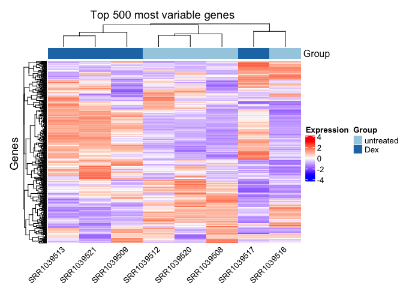

```r
ind_to_keep <- c(which(colData(rld)$group=="untreated"), which(colData(rld)$group=="Dex"))
topVarGenes <- head(order(rowVars(assay(rld)[,ind_to_keep]), decreasing=TRUE), var_feature_n)

# set up gene expression matrix
mat1 <- assay(rld)[topVarGenes, ind_to_keep]

# scale matrix by each col. values
mat_scaled = t(apply(mat1, 1, scale))

# set up colors for heatmap
col = colorRamp2(c(-3, 0, 3), c("blue", "white", "red"))
cols1 <- brewer.pal(11, "Paired")
cols2 <- brewer.pal(9, "Greens")

# subset coldata for samples in untx and ex groups
colData_sub <- colData(dds)[ind_to_keep, ]

# set up annotation bar for samples
ha1 = HeatmapAnnotation(Group = colData_sub$group,
                        col = list(Group = c("untreated" = cols1[1], "Dex" = cols1[2])),
                                   show_legend = TRUE)

# se up column annotation labels (samples)
ha = columnAnnotation(x = anno_text(colData_sub$SRR,
                                    which="column", rot = 45,
                                    gp = gpar(fontsize = 10)))

# generate heatmap object
ht1 = Heatmap(mat_scaled, name = "Expression", col = col,
              top_annotation = c(ha1),
              bottom_annotation = c(ha),
              show_row_names = FALSE)

# plot the heatmap
draw(ht1, row_title = "Genes", column_title = "Top 500 most variable genes")
```

There does indeed seem to be relatively good clustering between untreated and Dex samples, suggesting there are unique gene expression programs defining the Dex samples from the untreated. However, one of these samples in the Dex group seems to be clustered further away from the other Dex samples. Why could this be, perhaps it is the sample that clustered away from the other samples on the PCA. We can add an annotation bar for the fake batch effect we created earlier to this plot to help us figure this out.

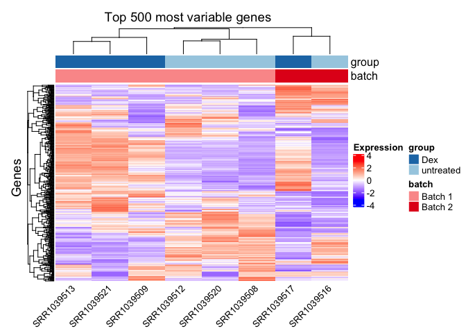

```r
colData_sub$batch <- "Batch 1"
colData_sub$batch[colData_sub$SRR=="SRR1039516"] <- "Batch 2"
colData_sub$batch[colData_sub$SRR=="SRR1039517"] <- "Batch 2"

# set up annotation bar for samples
ha1 = HeatmapAnnotation(group = c(as.character(colData_sub$group)),
                        batch = c(as.character(colData_sub$batch)),
                        col = list(group = c("untreated" = cols1[1], "Dex" = cols1[2]),
                                   batch = c("Batch 1" = cols1[5], "Batch 2" = cols1[6])),
                                   show_legend = TRUE)

# generate heatmap object
ht2 = Heatmap(mat_scaled, name = "Expression", col = col,
              top_annotation = c(ha1),
              bottom_annotation = c(ha),
              show_row_names = FALSE)

# plot the heatmap
draw(ht2, row_title = "Genes", column_title = "Top 500 most variable genes")
```

It seems that this is in fact the case, and these 2 samples are also outliers based on the hierachical clustering, which would support the presence of a batch effect if these data were infact collected in multiple batches.

We may also wish to cluster based on the pairwise correlations between gene expression samples, as this is again another complimenatry aproach to help us understand how the samples gene expression programs are rleated to each other.

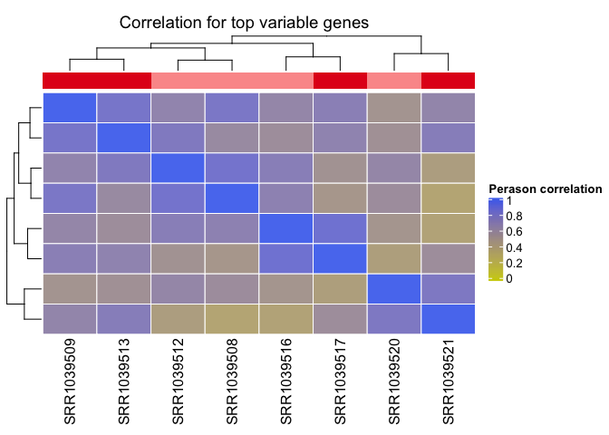

```r
rld_cor <- cor(assay(rld)[topVarGenes[1:50], ind_to_keep])

cols = colorRamp2(c(0, 1), c("yellow3", "royalblue2"), transparency = 0.1)
cols1 <- brewer.pal(11, "Paired")

# make heatmap annotations
ha1 = HeatmapAnnotation(group = as.factor(colData_sub$group),
                        show_legend = FALSE,
                        show_annotation_name = FALSE,
                        #text = anno_text(colData_sub$SRR, location = unit(1, "npc"), rot = 50, just = "right"),
                        col = list(group = c("untreated" = cols1[5], "Dex" = cols1[6])))

# generate heatmap object
ht_sub1 = Heatmap(rld_cor, name = "Perason correlation", col = cols,
                  rect_gp = gpar(col= "white"),
                  top_annotation = ha1, row_labels = rep("", 8))

# plot it
draw(ht_sub1, column_title = "Correlation for top variable genes")
```

That wraps up exploratory analysis. In the next R markdown, we will perform the differential expression analysis.